# Risk Factor Analysis

## Outcome Variable

**Outcome Variable:** y_rate_wtkg

## Predictor Variables

**Intervention Variable:** exclfeed36

**Adjustment Set:**

- arm
- sex
- brthmon
- W_mage
- meducyrs
- feducyrs
- hhwealth_quart
- hfoodsec
- W_mhtcm
- W_mwtkg
- W_mbmi
- vagbrth
- W_birthwt
- W_birthlen
- W_nrooms
- month
- W_parity
- impfloor
- impsan
- safeh20
- delta_W_mage
- delta_meducyrs
- delta_feducyrs
- delta_hhwealth_quart
- delta_hfoodsec
- delta_W_mhtcm
- delta_W_mwtkg
- delta_W_mbmi
- delta_vagbrth
- delta_W_birthwt
- delta_W_birthlen
- delta_W_nrooms
- delta_month
- delta_W_parity
- delta_impfloor
- delta_impsan
- delta_safeh20

## Stratifying Variables

The analysis was stratified on these variable(s):

- agecat
- studyid
- country

## Data Summary

| agecat | studyid | country | exclfeed36 | n_cell | n | outcome_variable |
| --- | --- | --- | --- | --- | --- | --- |
| 0-3 months | ki0047075b-MAL-ED | BANGLADESH | 1 | 32 | 245 | y_rate_wtkg |
| 0-3 months | ki0047075b-MAL-ED | BANGLADESH | 0 | 213 | 245 | y_rate_wtkg |
| 0-3 months | ki0047075b-MAL-ED | BRAZIL | 1 | 14 | 217 | y_rate_wtkg |
| 0-3 months | ki0047075b-MAL-ED | BRAZIL | 0 | 203 | 217 | y_rate_wtkg |
| 0-3 months | ki0047075b-MAL-ED | INDIA | 1 | 10 | 235 | y_rate_wtkg |
| 0-3 months | ki0047075b-MAL-ED | INDIA | 0 | 225 | 235 | y_rate_wtkg |
| 0-3 months | ki0047075b-MAL-ED | NEPAL | 1 | 5 | 230 | y_rate_wtkg |
| 0-3 months | ki0047075b-MAL-ED | NEPAL | 0 | 225 | 230 | y_rate_wtkg |
| 0-3 months | ki0047075b-MAL-ED | PERU | 1 | 7 | 280 | y_rate_wtkg |
| 0-3 months | ki0047075b-MAL-ED | PERU | 0 | 273 | 280 | y_rate_wtkg |
| 0-3 months | ki0047075b-MAL-ED | SOUTH AFRICA | 1 | 3 | 268 | y_rate_wtkg |
| 0-3 months | ki0047075b-MAL-ED | SOUTH AFRICA | 0 | 265 | 268 | y_rate_wtkg |
| 0-3 months | ki0047075b-MAL-ED | TANZANIA, UNITED REPUBLIC OF | 1 | 3 | 232 | y_rate_wtkg |
| 0-3 months | ki0047075b-MAL-ED | TANZANIA, UNITED REPUBLIC OF | 0 | 229 | 232 | y_rate_wtkg |
| 0-3 months | ki1000108-CMC-V-BCS-2002 | INDIA | 1 | 6 | 6 | y_rate_wtkg |
| 0-3 months | ki1000108-CMC-V-BCS-2002 | INDIA | 0 | 0 | 6 | y_rate_wtkg |
| 0-3 months | ki1000108-IRC | INDIA | 1 | 0 | 4 | y_rate_wtkg |
| 0-3 months | ki1000108-IRC | INDIA | 0 | 4 | 4 | y_rate_wtkg |
| 0-3 months | ki1000109-EE | PAKISTAN | 1 | 3 | 7 | y_rate_wtkg |
| 0-3 months | ki1000109-EE | PAKISTAN | 0 | 4 | 7 | y_rate_wtkg |
| 0-3 months | ki1017093b-PROVIDE | BANGLADESH | 1 | 161 | 634 | y_rate_wtkg |
| 0-3 months | ki1017093b-PROVIDE | BANGLADESH | 0 | 473 | 634 | y_rate_wtkg |
| 0-3 months | ki1101329-Keneba | GAMBIA | 1 | 400 | 1384 | y_rate_wtkg |
| 0-3 months | ki1101329-Keneba | GAMBIA | 0 | 984 | 1384 | y_rate_wtkg |
| 0-3 months | ki1113344-GMS-Nepal | NEPAL | 1 | 373 | 466 | y_rate_wtkg |
| 0-3 months | ki1113344-GMS-Nepal | NEPAL | 0 | 93 | 466 | y_rate_wtkg |
| 0-3 months | kiGH5241-JiVitA-3 | BANGLADESH | 1 | 7719 | 9920 | y_rate_wtkg |
| 0-3 months | kiGH5241-JiVitA-3 | BANGLADESH | 0 | 2201 | 9920 | y_rate_wtkg |
| 0-3 months | kiGH5241-JiVitA-4 | BANGLADESH | 1 | 1912 | 2293 | y_rate_wtkg |
| 0-3 months | kiGH5241-JiVitA-4 | BANGLADESH | 0 | 381 | 2293 | y_rate_wtkg |

[output cut: 214 more lines]

The following strata were considered:

- agecat: 0-3 months, studyid: ki0047075b-MAL-ED, country: BANGLADESH
- agecat: 0-3 months, studyid: ki0047075b-MAL-ED, country: BRAZIL
- agecat: 0-3 months, studyid: ki0047075b-MAL-ED, country: INDIA
- agecat: 0-3 months, studyid: ki0047075b-MAL-ED, country: NEPAL
- agecat: 0-3 months, studyid: ki0047075b-MAL-ED, country: PERU
- agecat: 0-3 months, studyid: ki0047075b-MAL-ED, country: SOUTH AFRICA
- agecat: 0-3 months, studyid: ki0047075b-MAL-ED, country: TANZANIA, UNITED REPUBLIC OF
- agecat: 0-3 months, studyid: ki1000108-CMC-V-BCS-2002, country: INDIA
- agecat: 0-3 months, studyid: ki1000108-IRC, country: INDIA
- agecat: 0-3 months, studyid: ki1000109-EE, country: PAKISTAN
- agecat: 0-3 months, studyid: ki1017093b-PROVIDE, country: BANGLADESH
- agecat: 0-3 months, studyid: ki1101329-Keneba, country: GAMBIA
- agecat: 0-3 months, studyid: ki1113344-GMS-Nepal, country: NEPAL
- agecat: 0-3 months, studyid: kiGH5241-JiVitA-3, country: BANGLADESH
- agecat: 0-3 months, studyid: kiGH5241-JiVitA-4, country: BANGLADESH
- agecat: 12-15 months, studyid: ki0047075b-MAL-ED, country: BANGLADESH
- agecat: 12-15 months, studyid: ki0047075b-MAL-ED, country: BRAZIL
- agecat: 12-15 months, studyid: ki0047075b-MAL-ED, country: INDIA
- agecat: 12-15 months, studyid: ki0047075b-MAL-ED, country: NEPAL
- agecat: 12-15 months, studyid: ki0047075b-MAL-ED, country: PERU
- agecat: 12-15 months, studyid: ki0047075b-MAL-ED, country: SOUTH AFRICA
- agecat: 12-15 months, studyid: ki0047075b-MAL-ED, country: TANZANIA, UNITED REPUBLIC OF
- agecat: 12-15 months, studyid: ki1000108-CMC-V-BCS-2002, country: INDIA
- agecat: 12-15 months, studyid: ki1000108-IRC, country: INDIA
- agecat: 12-15 months, studyid: ki1000109-EE, country: PAKISTAN
- agecat: 12-15 months, studyid: ki1000304b-SAS-FoodSuppl, country: INDIA
- agecat: 12-15 months, studyid: ki1017093b-PROVIDE, country: BANGLADESH
- agecat: 12-15 months, studyid: ki1101329-Keneba, country: GAMBIA
- agecat: 12-15 months, studyid: ki1113344-GMS-Nepal, country: NEPAL
- agecat: 12-15 months, studyid: ki1148112-LCNI-5, country: MALAWI
- agecat: 12-15 months, studyid: kiGH5241-JiVitA-4, country: BANGLADESH
- agecat: 15-18 months, studyid: ki0047075b-MAL-ED, country: BANGLADESH
- agecat: 15-18 months, studyid: ki0047075b-MAL-ED, country: BRAZIL
- agecat: 15-18 months, studyid: ki0047075b-MAL-ED, country: INDIA
- agecat: 15-18 months, studyid: ki0047075b-MAL-ED, country: NEPAL
- agecat: 15-18 months, studyid: ki0047075b-MAL-ED, country: PERU
- agecat: 15-18 months, studyid: ki0047075b-MAL-ED, country: SOUTH AFRICA
- agecat: 15-18 months, studyid: ki0047075b-MAL-ED, country: TANZANIA, UNITED REPUBLIC OF
- agecat: 15-18 months, studyid: ki1000108-CMC-V-BCS-2002, country: INDIA
- agecat: 15-18 months, studyid: ki1000108-IRC, country: INDIA
- agecat: 15-18 months, studyid: ki1000109-EE, country: PAKISTAN
- agecat: 15-18 months, studyid: ki1000304b-SAS-FoodSuppl, country: INDIA
- agecat: 15-18 months, studyid: ki1017093b-PROVIDE, country: BANGLADESH
- agecat: 15-18 months, studyid: ki1101329-Keneba, country: GAMBIA
- agecat: 15-18 months, studyid: ki1113344-GMS-Nepal, country: NEPAL
- agecat: 15-18 months, studyid: ki1148112-LCNI-5, country: MALAWI
- agecat: 15-18 months, studyid: kiGH5241-JiVitA-4, country: BANGLADESH
- agecat: 18-21 months, studyid: ki0047075b-MAL-ED, country: BANGLADESH
- agecat: 18-21 months, studyid: ki0047075b-MAL-ED, country: BRAZIL
- agecat: 18-21 months, studyid: ki0047075b-MAL-ED, country: INDIA
- agecat: 18-21 months, studyid: ki0047075b-MAL-ED, country: NEPAL
- agecat: 18-21 months, studyid: ki0047075b-MAL-ED, country: PERU
- agecat: 18-21 months, studyid: ki0047075b-MAL-ED, country: SOUTH AFRICA
- agecat: 18-21 months, studyid: ki0047075b-MAL-ED, country: TANZANIA, UNITED REPUBLIC OF
- agecat: 18-21 months, studyid: ki1000108-CMC-V-BCS-2002, country: INDIA
- agecat: 18-21 months, studyid: ki1000108-IRC, country: INDIA
- agecat: 18-21 months, studyid: ki1000109-EE, country: PAKISTAN
- agecat: 18-21 months, studyid: ki1017093b-PROVIDE, country: BANGLADESH
- agecat: 18-21 months, studyid: ki1101329-Keneba, country: GAMBIA
- agecat: 18-21 months, studyid: ki1113344-GMS-Nepal, country: NEPAL
- agecat: 18-21 months, studyid: ki1148112-LCNI-5, country: MALAWI
- agecat: 21-24 months, studyid: ki0047075b-MAL-ED, country: BANGLADESH
- agecat: 21-24 months, studyid: ki0047075b-MAL-ED, country: BRAZIL
- agecat: 21-24 months, studyid: ki0047075b-MAL-ED, country: INDIA
- agecat: 21-24 months, studyid: ki0047075b-MAL-ED, country: NEPAL
- agecat: 21-24 months, studyid: ki0047075b-MAL-ED, country: PERU
- agecat: 21-24 months, studyid: ki0047075b-MAL-ED, country: SOUTH AFRICA
- agecat: 21-24 months, studyid: ki0047075b-MAL-ED, country: TANZANIA, UNITED REPUBLIC OF
- agecat: 21-24 months, studyid: ki1000108-CMC-V-BCS-2002, country: INDIA
- agecat: 21-24 months, studyid: ki1000108-IRC, country: INDIA
- agecat: 21-24 months, studyid: ki1000109-EE, country: PAKISTAN
- agecat: 21-24 months, studyid: ki1017093b-PROVIDE, country: BANGLADESH
- agecat: 21-24 months, studyid: ki1101329-Keneba, country: GAMBIA
- agecat: 21-24 months, studyid: ki1113344-GMS-Nepal, country: NEPAL
- agecat: 21-24 months, studyid: ki1148112-LCNI-5, country: MALAWI
- agecat: 3-6 months, studyid: ki0047075b-MAL-ED, country: BANGLADESH
- agecat: 3-6 months, studyid: ki0047075b-MAL-ED, country: BRAZIL
- agecat: 3-6 months, studyid: ki0047075b-MAL-ED, country: INDIA
- agecat: 3-6 months, studyid: ki0047075b-MAL-ED, country: NEPAL
- agecat: 3-6 months, studyid: ki0047075b-MAL-ED, country: PERU
- agecat: 3-6 months, studyid: ki0047075b-MAL-ED, country: SOUTH AFRICA
- agecat: 3-6 months, studyid: ki0047075b-MAL-ED, country: TANZANIA, UNITED REPUBLIC OF
- agecat: 3-6 months, studyid: ki1000108-CMC-V-BCS-2002, country: INDIA
- agecat: 3-6 months, studyid: ki1000108-IRC, country: INDIA
- agecat: 3-6 months, studyid: ki1000109-EE, country: PAKISTAN
- agecat: 3-6 months, studyid: ki1017093b-PROVIDE, country: BANGLADESH
- agecat: 3-6 months, studyid: ki1101329-Keneba, country: GAMBIA
- agecat: 3-6 months, studyid: ki1113344-GMS-Nepal, country: NEPAL
- agecat: 3-6 months, studyid: kiGH5241-JiVitA-3, country: BANGLADESH
- agecat: 3-6 months, studyid: kiGH5241-JiVitA-4, country: BANGLADESH
- agecat: 6-9 months, studyid: ki0047075b-MAL-ED, country: BANGLADESH
- agecat: 6-9 months, studyid: ki0047075b-MAL-ED, country: BRAZIL
- agecat: 6-9 months, studyid: ki0047075b-MAL-ED, country: INDIA
- agecat: 6-9 months, studyid: ki0047075b-MAL-ED, country: NEPAL
- agecat: 6-9 months, studyid: ki0047075b-MAL-ED, country: PERU
- agecat: 6-9 months, studyid: ki0047075b-MAL-ED, country: SOUTH AFRICA
- agecat: 6-9 months, studyid: ki0047075b-MAL-ED, country: TANZANIA, UNITED REPUBLIC OF
- agecat: 6-9 months, studyid: ki1000108-CMC-V-BCS-2002, country: INDIA
- agecat: 6-9 months, studyid: ki1000108-IRC, country: INDIA
- agecat: 6-9 months, studyid: ki1000109-EE, country: PAKISTAN
- agecat: 6-9 months, studyid: ki1000304b-SAS-FoodSuppl, country: INDIA
- agecat: 6-9 months, studyid: ki1017093b-PROVIDE, country: BANGLADESH
- agecat: 6-9 months, studyid: ki1101329-Keneba, country: GAMBIA
- agecat: 6-9 months, studyid: ki1113344-GMS-Nepal, country: NEPAL
- agecat: 6-9 months, studyid: ki1148112-LCNI-5, country: MALAWI
- agecat: 6-9 months, studyid: kiGH5241-JiVitA-4, country: BANGLADESH
- agecat: 9-12 months, studyid: ki0047075b-MAL-ED, country: BANGLADESH
- agecat: 9-12 months, studyid: ki0047075b-MAL-ED, country: BRAZIL
- agecat: 9-12 months, studyid: ki0047075b-MAL-ED, country: INDIA
- agecat: 9-12 months, studyid: ki0047075b-MAL-ED, country: NEPAL
- agecat: 9-12 months, studyid: ki0047075b-MAL-ED, country: PERU
- agecat: 9-12 months, studyid: ki0047075b-MAL-ED, country: SOUTH AFRICA
- agecat: 9-12 months, studyid: ki0047075b-MAL-ED, country: TANZANIA, UNITED REPUBLIC OF
- agecat: 9-12 months, studyid: ki1000108-CMC-V-BCS-2002, country: INDIA
- agecat: 9-12 months, studyid: ki1000108-IRC, country: INDIA
- agecat: 9-12 months, studyid: ki1000109-EE, country: PAKISTAN
- agecat: 9-12 months, studyid: ki1000304b-SAS-FoodSuppl, country: INDIA
- agecat: 9-12 months, studyid: ki1017093b-PROVIDE, country: BANGLADESH
- agecat: 9-12 months, studyid: ki1101329-Keneba, country: GAMBIA
- agecat: 9-12 months, studyid: ki1113344-GMS-Nepal, country: NEPAL
- agecat: 9-12 months, studyid: ki1148112-LCNI-5, country: MALAWI
- agecat: 9-12 months, studyid: kiGH5241-JiVitA-4, country: BANGLADESH

### Dropped Strata

Some strata were dropped due to rare outcomes:

- agecat: 0-3 months, studyid: ki0047075b-MAL-ED, country: SOUTH AFRICA
- agecat: 0-3 months, studyid: ki0047075b-MAL-ED, country: TANZANIA, UNITED REPUBLIC OF
- agecat: 0-3 months, studyid: ki1000108-CMC-V-BCS-2002, country: INDIA
- agecat: 0-3 months, studyid: ki1000108-IRC, country: INDIA
- agecat: 0-3 months, studyid: ki1000109-EE, country: PAKISTAN
- agecat: 3-6 months, studyid: ki0047075b-MAL-ED, country: NEPAL
- agecat: 3-6 months, studyid: ki0047075b-MAL-ED, country: SOUTH AFRICA
- agecat: 3-6 months, studyid: ki0047075b-MAL-ED, country: TANZANIA, UNITED REPUBLIC OF
- agecat: 3-6 months, studyid: ki1000108-CMC-V-BCS-2002, country: INDIA
- agecat: 3-6 months, studyid: ki1000108-IRC, country: INDIA
- agecat: 3-6 months, studyid: ki1000109-EE, country: PAKISTAN
- agecat: 6-9 months, studyid: ki0047075b-MAL-ED, country: NEPAL
- agecat: 6-9 months, studyid: ki0047075b-MAL-ED, country: SOUTH AFRICA
- agecat: 6-9 months, studyid: ki0047075b-MAL-ED, country: TANZANIA, UNITED REPUBLIC OF
- agecat: 6-9 months, studyid: ki1000108-CMC-V-BCS-2002, country: INDIA
- agecat: 6-9 months, studyid: ki1000108-IRC, country: INDIA
- agecat: 6-9 months, studyid: ki1000109-EE, country: PAKISTAN
- agecat: 6-9 months, studyid: ki1000304b-SAS-FoodSuppl, country: INDIA
- agecat: 9-12 months, studyid: ki0047075b-MAL-ED, country: NEPAL
- agecat: 9-12 months, studyid: ki0047075b-MAL-ED, country: SOUTH AFRICA
- agecat: 9-12 months, studyid: ki0047075b-MAL-ED, country: TANZANIA, UNITED REPUBLIC OF
- agecat: 9-12 months, studyid: ki1000108-CMC-V-BCS-2002, country: INDIA
- agecat: 9-12 months, studyid: ki1000108-IRC, country: INDIA
- agecat: 9-12 months, studyid: ki1000109-EE, country: PAKISTAN
- agecat: 9-12 months, studyid: ki1000304b-SAS-FoodSuppl, country: INDIA
- agecat: 12-15 months, studyid: ki0047075b-MAL-ED, country: NEPAL
- agecat: 12-15 months, studyid: ki0047075b-MAL-ED, country: SOUTH AFRICA
- agecat: 12-15 months, studyid: ki0047075b-MAL-ED, country: TANZANIA, UNITED REPUBLIC OF
- agecat: 12-15 months, studyid: ki1000108-CMC-V-BCS-2002, country: INDIA
- agecat: 12-15 months, studyid: ki1000108-IRC, country: INDIA
- agecat: 12-15 months, studyid: ki1000109-EE, country: PAKISTAN
- agecat: 12-15 months, studyid: ki1000304b-SAS-FoodSuppl, country: INDIA
- agecat: 12-15 months, studyid: ki1148112-LCNI-5, country: MALAWI
- agecat: 15-18 months, studyid: ki0047075b-MAL-ED, country: NEPAL
- agecat: 15-18 months, studyid: ki0047075b-MAL-ED, country: SOUTH AFRICA
- agecat: 15-18 months, studyid: ki0047075b-MAL-ED, country: TANZANIA, UNITED REPUBLIC OF
- agecat: 15-18 months, studyid: ki1000108-CMC-V-BCS-2002, country: INDIA
- agecat: 15-18 months, studyid: ki1000108-IRC, country: INDIA
- agecat: 15-18 months, studyid: ki1000109-EE, country: PAKISTAN
- agecat: 15-18 months, studyid: ki1000304b-SAS-FoodSuppl, country: INDIA
- agecat: 15-18 months, studyid: ki1148112-LCNI-5, country: MALAWI
- agecat: 18-21 months, studyid: ki0047075b-MAL-ED, country: NEPAL
- agecat: 18-21 months, studyid: ki0047075b-MAL-ED, country: PERU
- agecat: 18-21 months, studyid: ki0047075b-MAL-ED, country: SOUTH AFRICA
- agecat: 18-21 months, studyid: ki0047075b-MAL-ED, country: TANZANIA, UNITED REPUBLIC OF
- agecat: 18-21 months, studyid: ki1000108-CMC-V-BCS-2002, country: INDIA
- agecat: 18-21 months, studyid: ki1000108-IRC, country: INDIA
- agecat: 18-21 months, studyid: ki1000109-EE, country: PAKISTAN
- agecat: 21-24 months, studyid: ki0047075b-MAL-ED, country: NEPAL
- agecat: 21-24 months, studyid: ki0047075b-MAL-ED, country: PERU
- agecat: 21-24 months, studyid: ki0047075b-MAL-ED, country: SOUTH AFRICA
- agecat: 21-24 months, studyid: ki0047075b-MAL-ED, country: TANZANIA, UNITED REPUBLIC OF
- agecat: 21-24 months, studyid: ki1000108-CMC-V-BCS-2002, country: INDIA
- agecat: 21-24 months, studyid: ki1000108-IRC, country: INDIA
- agecat: 21-24 months, studyid: ki1000109-EE, country: PAKISTAN

## Methods Detail

We’re interested in the causal parameters $E[Y_a]$ for all values of $a \in \mathcal{A}$. These parameters represent the mean outcome if, possibly contrary to fact, we intervened to set all units to have $A=a$. Under the randomization and positivity assumptions, these are identified by the statistical parameters $\psi_a=E_W[E_{Y|A,W}(Y|A=a,W)]$. In addition, we’re interested in the mean of $Y$, $E[Y]$ under no intervention (the observed mean). We will estimate these parameters by using SuperLearner to fit the relevant likelihood factors – $E_{Y|A,W}(Y|A=a,W)$ and $p(A=a|W)$, and then updating our likelihood fit using a joint TMLE.

For unadjusted analyses ($W=\{\}$), initial likelihoods were estimated using Lrnr_glm to estimate the simple $E(Y|A)$ and Lrnr_mean to estimate $p(A)$. For adjusted analyses, a small library containing Lrnr_glmnet, Lrnr_xgboost, and Lrnr_mean was used.

Having estimated these parameters, we will then use the delta method to estimate relative risks and attributable risks relative to a prespecified baseline level of $A$.

# Results Detail

## Results Plots

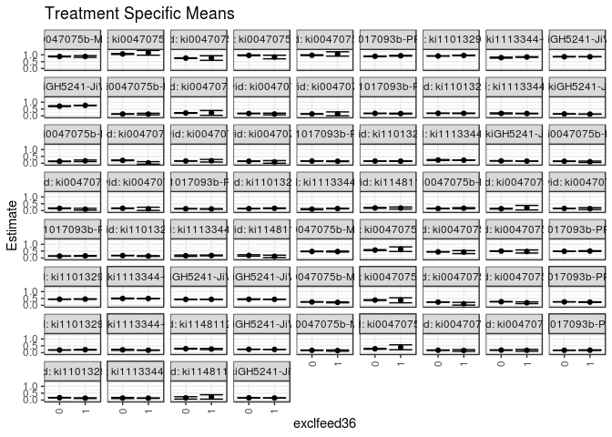

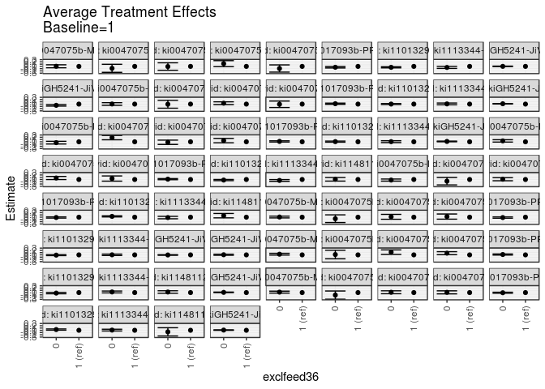

[figure not shown]

## Results Table

### Parameter: TSM

| agecat | studyid | country | intervention_level | baseline_level | estimate | ci_lower | ci_upper |
| --- | --- | --- | --- | --- | --- | --- | --- |
| 0-3 months | ki0047075b-MAL-ED | BANGLADESH | 1 | NA | 0.8739106 | 0.8126920 | 0.9351291 |
| 0-3 months | ki0047075b-MAL-ED | BANGLADESH | 0 | NA | 0.8786592 | 0.8536635 | 0.9036550 |
| 0-3 months | ki0047075b-MAL-ED | BRAZIL | 1 | NA | 1.1456029 | 0.9705937 | 1.3206121 |
| 0-3 months | ki0047075b-MAL-ED | BRAZIL | 0 | NA | 1.0598673 | 1.0247177 | 1.0950168 |
| 0-3 months | ki0047075b-MAL-ED | INDIA | 1 | NA | 0.7646341 | 0.6006741 | 0.9285942 |
| 0-3 months | ki0047075b-MAL-ED | INDIA | 0 | NA | 0.7576869 | 0.7349145 | 0.7804593 |
| 0-3 months | ki0047075b-MAL-ED | NEPAL | 1 | NA | 0.8372995 | 0.7064060 | 0.9681929 |
| 0-3 months | ki0047075b-MAL-ED | NEPAL | 0 | NA | 0.9593001 | 0.9319184 | 0.9866818 |
| 0-3 months | ki0047075b-MAL-ED | PERU | 1 | NA | 1.0619875 | 0.9042981 | 1.2196769 |
| 0-3 months | ki0047075b-MAL-ED | PERU | 0 | NA | 0.9686296 | 0.9431775 | 0.9940816 |
| 0-3 months | ki1017093b-PROVIDE | BANGLADESH | 1 | NA | 0.9314520 | 0.9051613 | 0.9577428 |
| 0-3 months | ki1017093b-PROVIDE | BANGLADESH | 0 | NA | 0.8923978 | 0.8751991 | 0.9095964 |
| 0-3 months | ki1101329-Keneba | GAMBIA | 1 | NA | 0.9543888 | 0.9342257 | 0.9745520 |
| 0-3 months | ki1101329-Keneba | GAMBIA | 0 | NA | 0.9125876 | 0.8985448 | 0.9266303 |
| 0-3 months | ki1113344-GMS-Nepal | NEPAL | 1 | NA | 0.8383022 | 0.8182787 | 0.8583258 |
| 0-3 months | ki1113344-GMS-Nepal | NEPAL | 0 | NA | 0.7917617 | 0.7526299 | 0.8308935 |
| 0-3 months | kiGH5241-JiVitA-3 | BANGLADESH | 1 | NA | 0.8558194 | 0.8513903 | 0.8602486 |
| 0-3 months | kiGH5241-JiVitA-3 | BANGLADESH | 0 | NA | 0.8575626 | 0.8484026 | 0.8667227 |
| 0-3 months | kiGH5241-JiVitA-4 | BANGLADESH | 1 | NA | 0.7617037 | 0.7471901 | 0.7762174 |
| 0-3 months | kiGH5241-JiVitA-4 | BANGLADESH | 0 | NA | 0.7076813 | 0.6755615 | 0.7398011 |
| 3-6 months | ki0047075b-MAL-ED | BANGLADESH | 1 | NA | 0.4674570 | 0.4332072 | 0.5017069 |
| 3-6 months | ki0047075b-MAL-ED | BANGLADESH | 0 | NA | 0.4746994 | 0.4559241 | 0.4934747 |
| 3-6 months | ki0047075b-MAL-ED | BRAZIL | 1 | NA | 0.6409587 | 0.4731190 | 0.8087984 |
| 3-6 months | ki0047075b-MAL-ED | BRAZIL | 0 | NA | 0.5741130 | 0.5423584 | 0.6058677 |
| 3-6 months | ki0047075b-MAL-ED | INDIA | 1 | NA | 0.4279072 | 0.3201283 | 0.5356861 |
| 3-6 months | ki0047075b-MAL-ED | INDIA | 0 | NA | 0.4443757 | 0.4266827 | 0.4620687 |
| 3-6 months | ki0047075b-MAL-ED | PERU | 1 | NA | 0.4723659 | 0.3597202 | 0.5850116 |
| 3-6 months | ki0047075b-MAL-ED | PERU | 0 | NA | 0.4988281 | 0.4796094 | 0.5180469 |
| 3-6 months | ki1017093b-PROVIDE | BANGLADESH | 1 | NA | 0.5021093 | 0.4777163 | 0.5265022 |
| 3-6 months | ki1017093b-PROVIDE | BANGLADESH | 0 | NA | 0.4856691 | 0.4703699 | 0.5009683 |

[output cut: 104 more lines]

### Parameter: E(Y)

| agecat | studyid | country | intervention_level | baseline_level | estimate | ci_lower | ci_upper |
| --- | --- | --- | --- | --- | --- | --- | --- |
| 0-3 months | ki0047075b-MAL-ED | BANGLADESH | NA | NA | 0.8793764 | 0.8562449 | 0.9025078 |
| 0-3 months | ki0047075b-MAL-ED | BRAZIL | NA | NA | 1.0655134 | 1.0311555 | 1.0998713 |
| 0-3 months | ki0047075b-MAL-ED | INDIA | NA | NA | 0.7588477 | 0.7364127 | 0.7812826 |
| 0-3 months | ki0047075b-MAL-ED | NEPAL | NA | NA | 0.9566479 | 0.9296524 | 0.9836434 |
| 0-3 months | ki0047075b-MAL-ED | PERU | NA | NA | 0.9709635 | 0.9457785 | 0.9961485 |
| 0-3 months | ki1017093b-PROVIDE | BANGLADESH | NA | NA | 0.9024472 | 0.8878738 | 0.9170206 |
| 0-3 months | ki1101329-Keneba | GAMBIA | NA | NA | 0.9245701 | 0.9128441 | 0.9362962 |
| 0-3 months | ki1113344-GMS-Nepal | NEPAL | NA | NA | 0.8290682 | 0.8112267 | 0.8469097 |
| 0-3 months | kiGH5241-JiVitA-3 | BANGLADESH | NA | NA | 0.8562140 | 0.8521272 | 0.8603009 |
| 0-3 months | kiGH5241-JiVitA-4 | BANGLADESH | NA | NA | 0.7527222 | 0.7394082 | 0.7660362 |
| 3-6 months | ki0047075b-MAL-ED | BANGLADESH | NA | NA | 0.4740560 | 0.4573508 | 0.4907612 |
| 3-6 months | ki0047075b-MAL-ED | BRAZIL | NA | NA | 0.5781976 | 0.5469697 | 0.6094254 |
| 3-6 months | ki0047075b-MAL-ED | INDIA | NA | NA | 0.4437256 | 0.4262017 | 0.4612496 |
| 3-6 months | ki0047075b-MAL-ED | PERU | NA | NA | 0.4982335 | 0.4792789 | 0.5171881 |
| 3-6 months | ki1017093b-PROVIDE | BANGLADESH | NA | NA | 0.4890611 | 0.4760060 | 0.5021163 |
| 3-6 months | ki1101329-Keneba | GAMBIA | NA | NA | 0.4465835 | 0.4366897 | 0.4564773 |
| 3-6 months | ki1113344-GMS-Nepal | NEPAL | NA | NA | 0.4969685 | 0.4829796 | 0.5109574 |
| 3-6 months | kiGH5241-JiVitA-3 | BANGLADESH | NA | NA | 0.4376750 | 0.4329472 | 0.4424029 |
| 3-6 months | kiGH5241-JiVitA-4 | BANGLADESH | NA | NA | 0.4386833 | 0.4295081 | 0.4478585 |
| 6-9 months | ki0047075b-MAL-ED | BANGLADESH | NA | NA | 0.2428552 | 0.2283339 | 0.2573765 |
| 6-9 months | ki0047075b-MAL-ED | BRAZIL | NA | NA | 0.3831499 | 0.3570859 | 0.4092138 |
| 6-9 months | ki0047075b-MAL-ED | INDIA | NA | NA | 0.2306231 | 0.2156296 | 0.2456166 |
| 6-9 months | ki0047075b-MAL-ED | PERU | NA | NA | 0.2613933 | 0.2459015 | 0.2768851 |
| 6-9 months | ki1017093b-PROVIDE | BANGLADESH | NA | NA | 0.2491653 | 0.2371134 | 0.2612172 |
| 6-9 months | ki1101329-Keneba | GAMBIA | NA | NA | 0.2005067 | 0.1873236 | 0.2136898 |
| 6-9 months | ki1113344-GMS-Nepal | NEPAL | NA | NA | 0.1871486 | 0.1748771 | 0.1994201 |
| 6-9 months | ki1148112-LCNI-5 | MALAWI | NA | NA | 0.2829175 | 0.2578313 | 0.3080037 |
| 6-9 months | kiGH5241-JiVitA-4 | BANGLADESH | NA | NA | 0.2387387 | 0.2332737 | 0.2442038 |
| 9-12 months | ki0047075b-MAL-ED | BANGLADESH | NA | NA | 0.1730346 | 0.1593686 | 0.1867006 |
| 9-12 months | ki0047075b-MAL-ED | BRAZIL | NA | NA | 0.2845923 | 0.2527896 | 0.3163950 |
| 9-12 months | ki0047075b-MAL-ED | INDIA | NA | NA | 0.1787492 | 0.1645237 | 0.1929747 |
| 9-12 months | ki0047075b-MAL-ED | PERU | NA | NA | 0.1874806 | 0.1721694 | 0.2027919 |
| 9-12 months | ki1017093b-PROVIDE | BANGLADESH | NA | NA | 0.1780389 | 0.1687408 | 0.1873370 |
| 9-12 months | ki1101329-Keneba | GAMBIA | NA | NA | 0.1608923 | 0.1478424 | 0.1739422 |
| 9-12 months | ki1113344-GMS-Nepal | NEPAL | NA | NA | 0.1395865 | 0.1265823 | 0.1525906 |
| 9-12 months | ki1148112-LCNI-5 | MALAWI | NA | NA | 0.1849664 | 0.1167599 | 0.2531730 |
| 9-12 months | kiGH5241-JiVitA-4 | BANGLADESH | NA | NA | 0.1533597 | 0.1488837 | 0.1578358 |
| 12-15 months | ki0047075b-MAL-ED | BANGLADESH | NA | NA | 0.1353586 | 0.1195861 | 0.1511312 |
| 12-15 months | ki0047075b-MAL-ED | BRAZIL | NA | NA | 0.2101946 | 0.1853699 | 0.2350192 |
| 12-15 months | ki0047075b-MAL-ED | INDIA | NA | NA | 0.1739653 | 0.1578765 | 0.1900541 |
| 12-15 months | ki0047075b-MAL-ED | PERU | NA | NA | 0.1417390 | 0.1250455 | 0.1584325 |
| 12-15 months | ki1017093b-PROVIDE | BANGLADESH | NA | NA | 0.1796101 | 0.1678900 | 0.1913301 |
| 12-15 months | ki1101329-Keneba | GAMBIA | NA | NA | 0.1891400 | 0.1785232 | 0.1997569 |
| 12-15 months | ki1113344-GMS-Nepal | NEPAL | NA | NA | 0.1746639 | 0.1610783 | 0.1882495 |
| 12-15 months | kiGH5241-JiVitA-4 | BANGLADESH | NA | NA | 0.1308582 | 0.1262352 | 0.1354811 |
| 15-18 months | ki0047075b-MAL-ED | BANGLADESH | NA | NA | 0.1427882 | 0.1271818 | 0.1583946 |
| 15-18 months | ki0047075b-MAL-ED | BRAZIL | NA | NA | 0.2034195 | 0.1767881 | 0.2300509 |
| 15-18 months | ki0047075b-MAL-ED | INDIA | NA | NA | 0.1642299 | 0.1493519 | 0.1791079 |
| 15-18 months | ki0047075b-MAL-ED | PERU | NA | NA | 0.1461889 | 0.1273267 | 0.1650511 |
| 15-18 months | ki1017093b-PROVIDE | BANGLADESH | NA | NA | 0.1558862 | 0.1440925 | 0.1676799 |
| 15-18 months | ki1101329-Keneba | GAMBIA | NA | NA | 0.1573149 | 0.1464971 | 0.1681327 |
| 15-18 months | ki1113344-GMS-Nepal | NEPAL | NA | NA | 0.2291397 | 0.2134657 | 0.2448138 |
| 15-18 months | kiGH5241-JiVitA-4 | BANGLADESH | NA | NA | 0.1598556 | 0.1545499 | 0.1651613 |
| 18-21 months | ki0047075b-MAL-ED | BANGLADESH | NA | NA | 0.1427146 | 0.1257942 | 0.1596351 |
| 18-21 months | ki0047075b-MAL-ED | BRAZIL | NA | NA | 0.1606491 | 0.1365241 | 0.1847741 |
| 18-21 months | ki0047075b-MAL-ED | INDIA | NA | NA | 0.1701596 | 0.1556514 | 0.1846677 |
| 18-21 months | ki1017093b-PROVIDE | BANGLADESH | NA | NA | 0.1324685 | 0.1209911 | 0.1439458 |
| 18-21 months | ki1101329-Keneba | GAMBIA | NA | NA | 0.1526855 | 0.1413636 | 0.1640074 |
| 18-21 months | ki1113344-GMS-Nepal | NEPAL | NA | NA | 0.1428759 | 0.1266216 | 0.1591302 |
| 18-21 months | ki1148112-LCNI-5 | MALAWI | NA | NA | 0.2016785 | 0.1726437 | 0.2307133 |
| 21-24 months | ki0047075b-MAL-ED | BANGLADESH | NA | NA | 0.1521155 | 0.1369898 | 0.1672413 |
| 21-24 months | ki0047075b-MAL-ED | BRAZIL | NA | NA | 0.1434900 | 0.1201394 | 0.1668407 |
| 21-24 months | ki0047075b-MAL-ED | INDIA | NA | NA | 0.1565193 | 0.1433011 | 0.1697376 |
| 21-24 months | ki1017093b-PROVIDE | BANGLADESH | NA | NA | 0.1419760 | 0.1304951 | 0.1534569 |
| 21-24 months | ki1101329-Keneba | GAMBIA | NA | NA | 0.1661358 | 0.1549650 | 0.1773065 |
| 21-24 months | ki1113344-GMS-Nepal | NEPAL | NA | NA | 0.1784694 | 0.1533807 | 0.2035582 |
| 21-24 months | ki1148112-LCNI-5 | MALAWI | NA | NA | 0.1779746 | 0.1356818 | 0.2202674 |

### Parameter: ATE

| agecat | studyid | country | intervention_level | baseline_level | estimate | ci_lower | ci_upper |
| --- | --- | --- | --- | --- | --- | --- | --- |
| 0-3 months | ki0047075b-MAL-ED | BANGLADESH | 1 | 1 | 0.0000000 | 0.0000000 | 0.0000000 |
| 0-3 months | ki0047075b-MAL-ED | BANGLADESH | 0 | 1 | 0.0047487 | -0.0613894 | 0.0708867 |
| 0-3 months | ki0047075b-MAL-ED | BRAZIL | 1 | 1 | 0.0000000 | 0.0000000 | 0.0000000 |
| 0-3 months | ki0047075b-MAL-ED | BRAZIL | 0 | 1 | -0.0857357 | -0.2639423 | 0.0924710 |
| 0-3 months | ki0047075b-MAL-ED | INDIA | 1 | 1 | 0.0000000 | 0.0000000 | 0.0000000 |
| 0-3 months | ki0047075b-MAL-ED | INDIA | 0 | 1 | -0.0069472 | -0.1724127 | 0.1585182 |
| 0-3 months | ki0047075b-MAL-ED | NEPAL | 1 | 1 | 0.0000000 | 0.0000000 | 0.0000000 |
| 0-3 months | ki0047075b-MAL-ED | NEPAL | 0 | 1 | 0.1220006 | -0.0117262 | 0.2557274 |
| 0-3 months | ki0047075b-MAL-ED | PERU | 1 | 1 | 0.0000000 | 0.0000000 | 0.0000000 |
| 0-3 months | ki0047075b-MAL-ED | PERU | 0 | 1 | -0.0933579 | -0.2530882 | 0.0663723 |
| 0-3 months | ki1017093b-PROVIDE | BANGLADESH | 1 | 1 | 0.0000000 | 0.0000000 | 0.0000000 |
| 0-3 months | ki1017093b-PROVIDE | BANGLADESH | 0 | 1 | -0.0390543 | -0.0702829 | -0.0078257 |
| 0-3 months | ki1101329-Keneba | GAMBIA | 1 | 1 | 0.0000000 | 0.0000000 | 0.0000000 |
| 0-3 months | ki1101329-Keneba | GAMBIA | 0 | 1 | -0.0418013 | -0.0661113 | -0.0174913 |
| 0-3 months | ki1113344-GMS-Nepal | NEPAL | 1 | 1 | 0.0000000 | 0.0000000 | 0.0000000 |
| 0-3 months | ki1113344-GMS-Nepal | NEPAL | 0 | 1 | -0.0465405 | -0.0905133 | -0.0025678 |
| 0-3 months | kiGH5241-JiVitA-3 | BANGLADESH | 1 | 1 | 0.0000000 | 0.0000000 | 0.0000000 |
| 0-3 months | kiGH5241-JiVitA-3 | BANGLADESH | 0 | 1 | 0.0017432 | -0.0082284 | 0.0117149 |
| 0-3 months | kiGH5241-JiVitA-4 | BANGLADESH | 1 | 1 | 0.0000000 | 0.0000000 | 0.0000000 |
| 0-3 months | kiGH5241-JiVitA-4 | BANGLADESH | 0 | 1 | -0.0540225 | -0.0892712 | -0.0187737 |
| 3-6 months | ki0047075b-MAL-ED | BANGLADESH | 1 | 1 | 0.0000000 | 0.0000000 | 0.0000000 |
| 3-6 months | ki0047075b-MAL-ED | BANGLADESH | 0 | 1 | 0.0072423 | -0.0322284 | 0.0467131 |
| 3-6 months | ki0047075b-MAL-ED | BRAZIL | 1 | 1 | 0.0000000 | 0.0000000 | 0.0000000 |
| 3-6 months | ki0047075b-MAL-ED | BRAZIL | 0 | 1 | -0.0668457 | -0.2375317 | 0.1038404 |
| 3-6 months | ki0047075b-MAL-ED | INDIA | 1 | 1 | 0.0000000 | 0.0000000 | 0.0000000 |
| 3-6 months | ki0047075b-MAL-ED | INDIA | 0 | 1 | 0.0164685 | -0.0927529 | 0.1256900 |
| 3-6 months | ki0047075b-MAL-ED | PERU | 1 | 1 | 0.0000000 | 0.0000000 | 0.0000000 |
| 3-6 months | ki0047075b-MAL-ED | PERU | 0 | 1 | 0.0264622 | -0.0878112 | 0.1407356 |
| 3-6 months | ki1017093b-PROVIDE | BANGLADESH | 1 | 1 | 0.0000000 | 0.0000000 | 0.0000000 |
| 3-6 months | ki1017093b-PROVIDE | BANGLADESH | 0 | 1 | -0.0164401 | -0.0452012 | 0.0123209 |

[output cut: 104 more lines]

### Parameter: PAR

| agecat | studyid | country | intervention_level | baseline_level | estimate | ci_lower | ci_upper |
| --- | --- | --- | --- | --- | --- | --- | --- |
| 0-3 months | ki0047075b-MAL-ED | BANGLADESH | 1 | NA | 0.0054658 | -0.0521708 | 0.0631024 |
| 0-3 months | ki0047075b-MAL-ED | BRAZIL | 1 | NA | -0.0800895 | -0.2495522 | 0.0893732 |
| 0-3 months | ki0047075b-MAL-ED | INDIA | 1 | NA | -0.0057865 | -0.1660352 | 0.1544622 |
| 0-3 months | ki0047075b-MAL-ED | NEPAL | 1 | NA | 0.1193484 | -0.0110556 | 0.2497524 |
| 0-3 months | ki0047075b-MAL-ED | PERU | 1 | NA | -0.0910240 | -0.2467704 | 0.0647224 |
| 0-3 months | ki1017093b-PROVIDE | BANGLADESH | 1 | NA | -0.0290049 | -0.0523864 | -0.0056233 |
| 0-3 months | ki1101329-Keneba | GAMBIA | 1 | NA | -0.0298187 | -0.0471450 | -0.0124924 |
| 0-3 months | ki1113344-GMS-Nepal | NEPAL | 1 | NA | -0.0092340 | -0.0181094 | -0.0003587 |
| 0-3 months | kiGH5241-JiVitA-3 | BANGLADESH | 1 | NA | 0.0003946 | -0.0018138 | 0.0026030 |
| 0-3 months | kiGH5241-JiVitA-4 | BANGLADESH | 1 | NA | -0.0089815 | -0.0148895 | -0.0030735 |
| 3-6 months | ki0047075b-MAL-ED | BANGLADESH | 1 | NA | 0.0065990 | -0.0280245 | 0.0412224 |
| 3-6 months | ki0047075b-MAL-ED | BRAZIL | 1 | NA | -0.0627611 | -0.2253105 | 0.0997882 |
| 3-6 months | ki0047075b-MAL-ED | INDIA | 1 | NA | 0.0158185 | -0.0890925 | 0.1207294 |
| 3-6 months | ki0047075b-MAL-ED | PERU | 1 | NA | 0.0258676 | -0.0855500 | 0.1372851 |
| 3-6 months | ki1017093b-PROVIDE | BANGLADESH | 1 | NA | -0.0130481 | -0.0350155 | 0.0089193 |
| 3-6 months | ki1101329-Keneba | GAMBIA | 1 | NA | -0.0075860 | -0.0240652 | 0.0088931 |
| 3-6 months | ki1113344-GMS-Nepal | NEPAL | 1 | NA | 0.0008774 | -0.0054702 | 0.0072249 |
| 3-6 months | kiGH5241-JiVitA-3 | BANGLADESH | 1 | NA | -0.0009319 | -0.0040895 | 0.0022258 |
| 3-6 months | kiGH5241-JiVitA-4 | BANGLADESH | 1 | NA | 0.0010365 | -0.0026195 | 0.0046925 |
| 6-9 months | ki0047075b-MAL-ED | BANGLADESH | 1 | NA | 0.0255006 | -0.0086724 | 0.0596736 |
| 6-9 months | ki0047075b-MAL-ED | BRAZIL | 1 | NA | 0.0155472 | -0.1630846 | 0.1941790 |
| 6-9 months | ki0047075b-MAL-ED | INDIA | 1 | NA | 0.1170074 | 0.0219593 | 0.2120555 |
| 6-9 months | ki0047075b-MAL-ED | PERU | 1 | NA | 0.0729598 | 0.0082049 | 0.1377146 |
| 6-9 months | ki1017093b-PROVIDE | BANGLADESH | 1 | NA | 0.0133153 | -0.0058321 | 0.0324627 |
| 6-9 months | ki1101329-Keneba | GAMBIA | 1 | NA | -0.0161299 | -0.0384533 | 0.0061934 |
| 6-9 months | ki1113344-GMS-Nepal | NEPAL | 1 | NA | 0.0057218 | -0.0023797 | 0.0138233 |
| 6-9 months | ki1148112-LCNI-5 | MALAWI | 1 | NA | 0.0180396 | -0.0298153 | 0.0658944 |
| 6-9 months | kiGH5241-JiVitA-4 | BANGLADESH | 1 | NA | 0.0019806 | -0.0005836 | 0.0045449 |
| 9-12 months | ki0047075b-MAL-ED | BANGLADESH | 1 | NA | 0.0185693 | -0.0194979 | 0.0566366 |
| 9-12 months | ki0047075b-MAL-ED | BRAZIL | 1 | NA | -0.1087488 | -0.2804190 | 0.0629214 |
| 9-12 months | ki0047075b-MAL-ED | INDIA | 1 | NA | 0.0135163 | -0.0490419 | 0.0760744 |
| 9-12 months | ki0047075b-MAL-ED | PERU | 1 | NA | 0.0105296 | -0.0547125 | 0.0757717 |
| 9-12 months | ki1017093b-PROVIDE | BANGLADESH | 1 | NA | -0.0044970 | -0.0215314 | 0.0125374 |
| 9-12 months | ki1101329-Keneba | GAMBIA | 1 | NA | 0.0225202 | 0.0031594 | 0.0418811 |
| 9-12 months | ki1113344-GMS-Nepal | NEPAL | 1 | NA | 0.0017455 | -0.0045617 | 0.0080527 |
| 9-12 months | ki1148112-LCNI-5 | MALAWI | 1 | NA | -0.0427421 | -0.1717032 | 0.0862190 |
| 9-12 months | kiGH5241-JiVitA-4 | BANGLADESH | 1 | NA | 0.0026086 | 0.0003076 | 0.0049095 |
| 12-15 months | ki0047075b-MAL-ED | BANGLADESH | 1 | NA | 0.0044034 | -0.0484659 | 0.0572727 |
| 12-15 months | ki0047075b-MAL-ED | BRAZIL | 1 | NA | -0.0075125 | -0.1733026 | 0.1582776 |
| 12-15 months | ki0047075b-MAL-ED | INDIA | 1 | NA | 0.0374922 | -0.0216640 | 0.0966484 |
| 12-15 months | ki0047075b-MAL-ED | PERU | 1 | NA | -0.0078303 | -0.1474527 | 0.1317921 |
| 12-15 months | ki1017093b-PROVIDE | BANGLADESH | 1 | NA | 0.0125856 | -0.0079167 | 0.0330879 |
| 12-15 months | ki1101329-Keneba | GAMBIA | 1 | NA | 0.0002047 | -0.0157773 | 0.0161867 |
| 12-15 months | ki1113344-GMS-Nepal | NEPAL | 1 | NA | 0.0013957 | -0.0053716 | 0.0081631 |
| 12-15 months | kiGH5241-JiVitA-4 | BANGLADESH | 1 | NA | 0.0030707 | 0.0006175 | 0.0055240 |
| 15-18 months | ki0047075b-MAL-ED | BANGLADESH | 1 | NA | -0.0336593 | -0.0860984 | 0.0187798 |
| 15-18 months | ki0047075b-MAL-ED | BRAZIL | 1 | NA | 0.1783261 | 0.0892288 | 0.2674235 |
| 15-18 months | ki0047075b-MAL-ED | INDIA | 1 | NA | -0.0209181 | -0.1117417 | 0.0699055 |
| 15-18 months | ki0047075b-MAL-ED | PERU | 1 | NA | 0.0524610 | -0.0422757 | 0.1471977 |
| 15-18 months | ki1017093b-PROVIDE | BANGLADESH | 1 | NA | 0.0116262 | -0.0078312 | 0.0310836 |
| 15-18 months | ki1101329-Keneba | GAMBIA | 1 | NA | 0.0044177 | -0.0118439 | 0.0206793 |
| 15-18 months | ki1113344-GMS-Nepal | NEPAL | 1 | NA | 0.0012064 | -0.0066582 | 0.0090710 |
| 15-18 months | kiGH5241-JiVitA-4 | BANGLADESH | 1 | NA | 0.0031132 | 0.0000662 | 0.0061602 |
| 18-21 months | ki0047075b-MAL-ED | BANGLADESH | 1 | NA | 0.0359832 | -0.0103278 | 0.0822942 |
| 18-21 months | ki0047075b-MAL-ED | BRAZIL | 1 | NA | 0.0598322 | -0.0059688 | 0.1256331 |
| 18-21 months | ki0047075b-MAL-ED | INDIA | 1 | NA | 0.0402515 | -0.0700091 | 0.1505121 |
| 18-21 months | ki1017093b-PROVIDE | BANGLADESH | 1 | NA | 0.0102554 | -0.0083086 | 0.0288194 |
| 18-21 months | ki1101329-Keneba | GAMBIA | 1 | NA | -0.0175996 | -0.0351741 | -0.0000252 |
| 18-21 months | ki1113344-GMS-Nepal | NEPAL | 1 | NA | -0.0076142 | -0.0150375 | -0.0001909 |
| 18-21 months | ki1148112-LCNI-5 | MALAWI | 1 | NA | 0.0139978 | -0.0527470 | 0.0807426 |
| 21-24 months | ki0047075b-MAL-ED | BANGLADESH | 1 | NA | -0.0251994 | -0.0657989 | 0.0154001 |
| 21-24 months | ki0047075b-MAL-ED | BRAZIL | 1 | NA | -0.0704601 | -0.2266470 | 0.0857269 |
| 21-24 months | ki0047075b-MAL-ED | INDIA | 1 | NA | 0.0115253 | -0.0544118 | 0.0774624 |
| 21-24 months | ki1017093b-PROVIDE | BANGLADESH | 1 | NA | -0.0111801 | -0.0310676 | 0.0087075 |
| 21-24 months | ki1101329-Keneba | GAMBIA | 1 | NA | 0.0251996 | 0.0076870 | 0.0427122 |
| 21-24 months | ki1113344-GMS-Nepal | NEPAL | 1 | NA | -0.0028522 | -0.0124371 | 0.0067327 |
| 21-24 months | ki1148112-LCNI-5 | MALAWI | 1 | NA | 0.0596063 | -0.0215261 | 0.1407386 |